# 1900 Paris Exposition

PH345: Winter 2026

Philip Boonstra

## 1900 Paris Exposition

World’s fair held April-November 1900

“Countries from around the world were invited by France to showcase their achievements and cultures”

https://en.wikipedia.org/wiki/Exposition_Universelle_(1900)

[figure not shown]

https://www.loc.gov/pictures/item/2007681990/

## American Negro Exhibit

Thomas J. Calloway and Booker T. Washington petitioned US government to include exhibit dedicated to social and economic progress of Black Americans: *The American Negro Exhibit*

Invited former classmate W.E.B DuBois to create social study of African American life

## W.E.B DuBois (1868-1963)

Black American sociologist, historian, novelist, and poet

Helped reorient field of sociology to be based on empiric data and charts

First African American to receive PhD from Harvard University

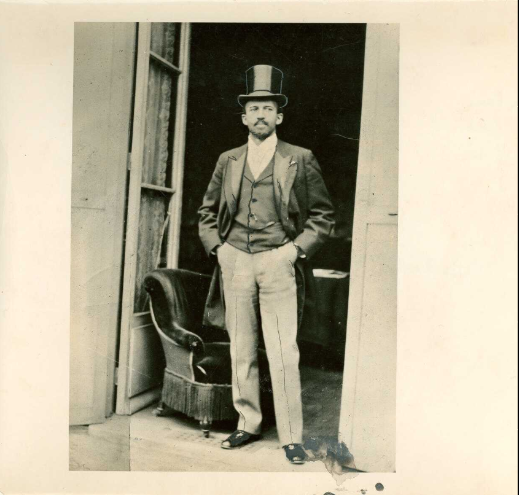

https://credo.library.umass.edu/view/full/mums312-i0396

DuBois and students from Atlanta University created two sets of infographics and data visualizations using data from DuBois’ own sociological laboratory and US Censur Bureau:

1. The Georgia Negro: A Social Study (36 plates)
2. A Series of Statistical Charts Illustrating the Condition of the Descendents of Former African Slaves Now Resident in the United States of America (37 plates)

Mix of traditional and unique bar plots, line plots, and pie charts with intentional use of color

## Three refutations

1. The Black race was not going extinct
   - contrast with social Darwinism
2. Highlighted Black American progress in spite of slavery, Jim Crow, and white supremacy
   - contrast with imperalist ethos of Exposition: lifting lower races out of barbarism (p19, Battle-Baptiste and Rusert)
3. Black Americans (and all those of African descent) had their own history, civilization, and culture, both within and separate from white America
   - “exploded mainstream ideas about the lack of Black accomplishments” (p7, Provenzo)

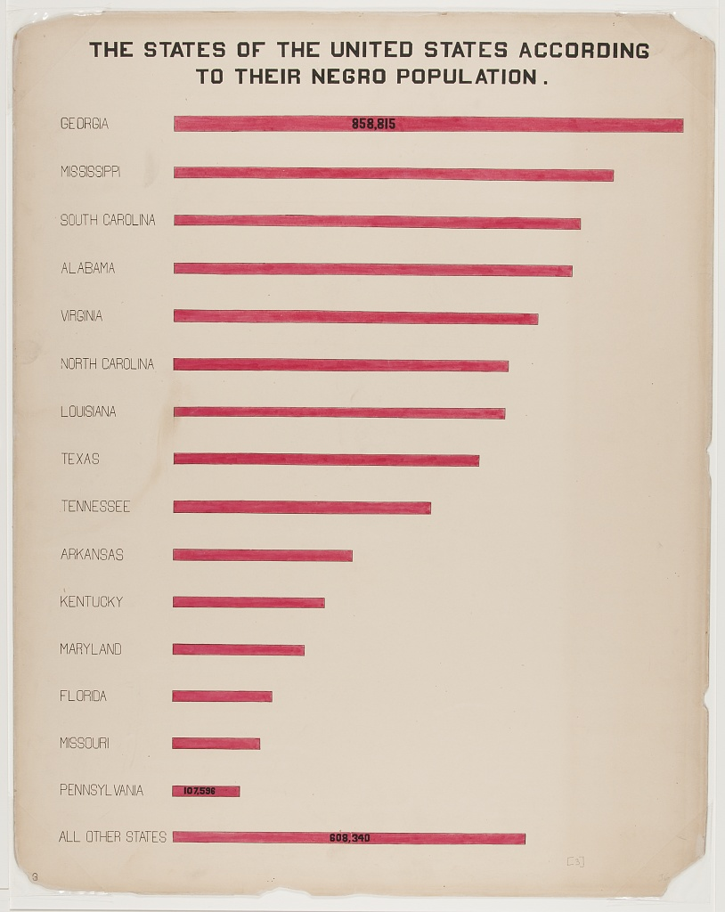

[Plate 3](https://www.loc.gov/pictures/collection/anedub/item/2013650422/)

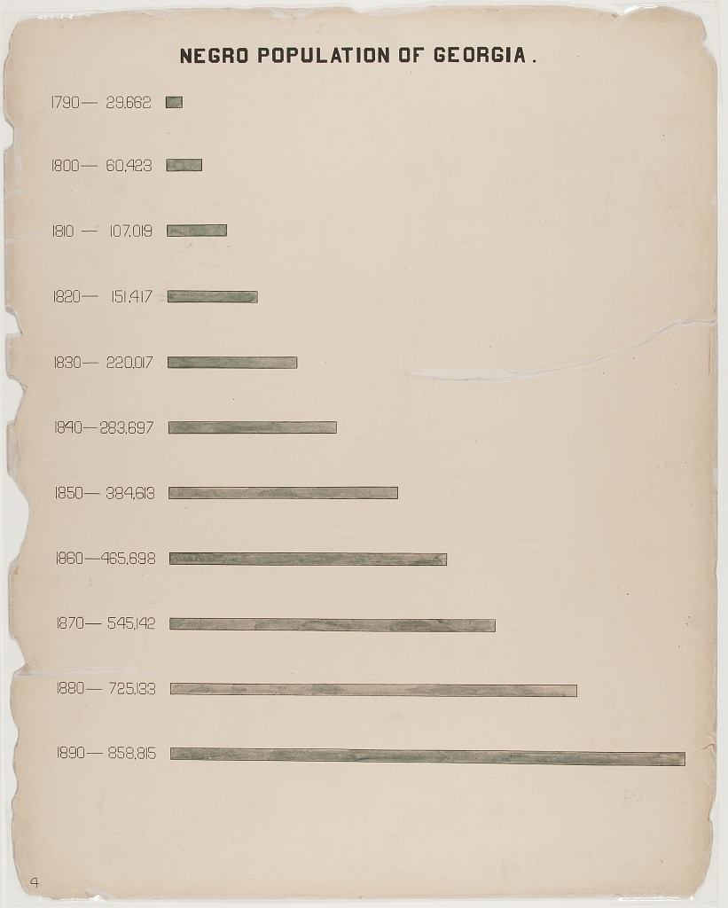

[Plate 4](https://www.loc.gov/pictures/collection/anedub/item/2013650423/)

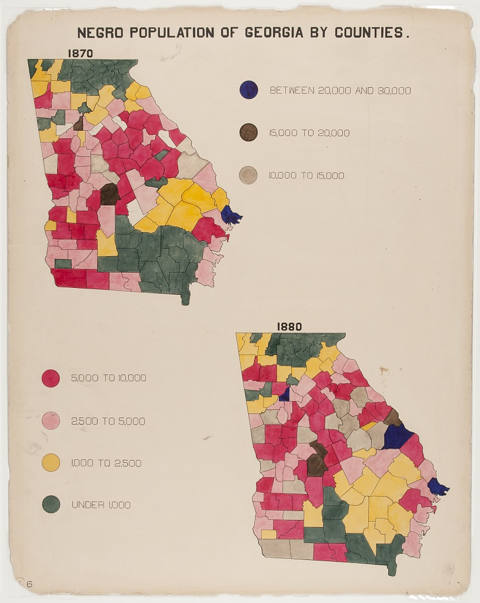

[Plate 6](https://www.loc.gov/pictures/collection/anedub/item/2013650425/)

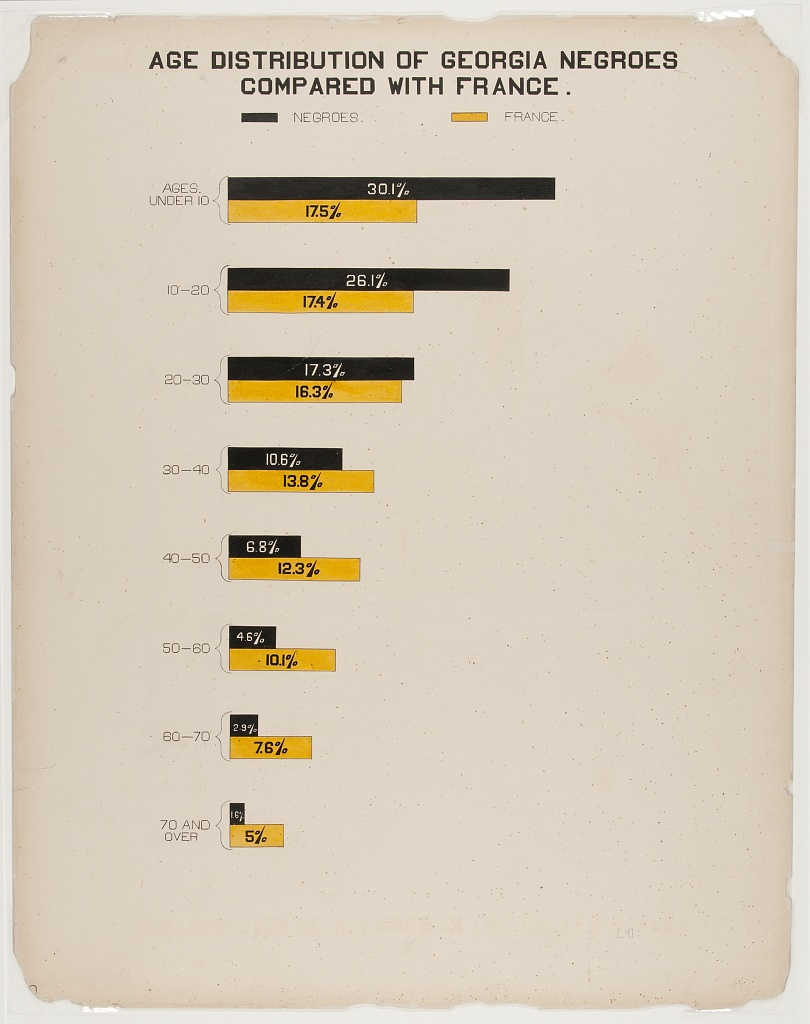

[Plate 9](https://www.loc.gov/pictures/collection/anedub/item/2013650428/)

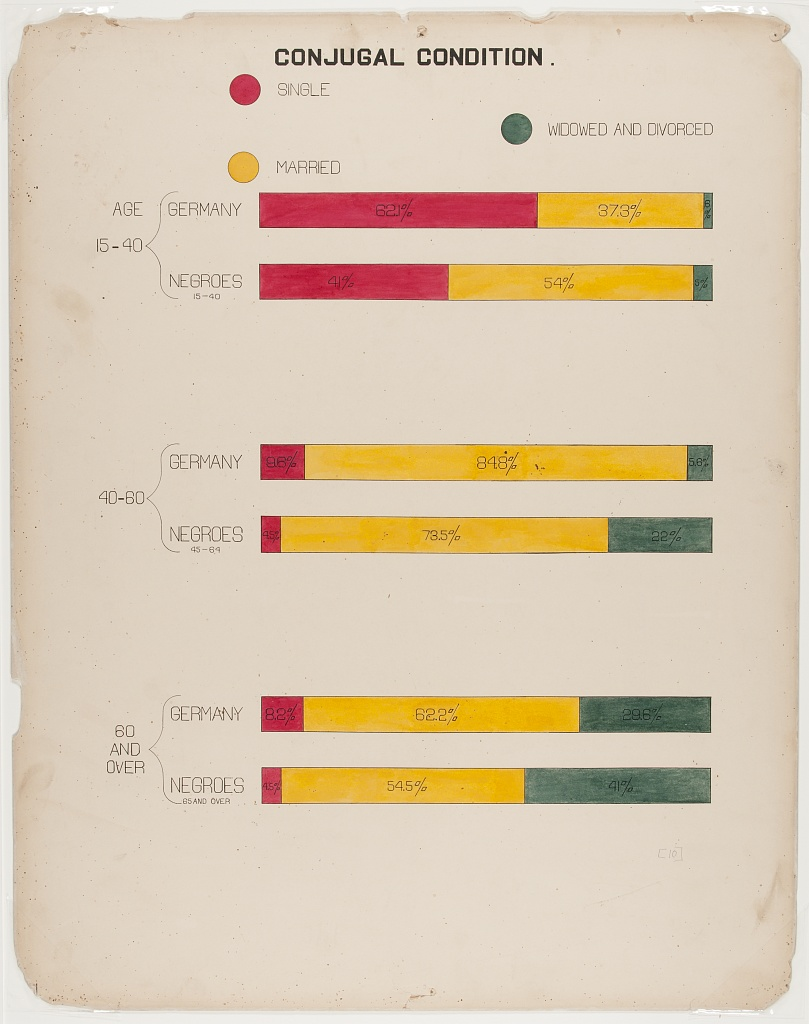

[Plate 10](https://www.loc.gov/pictures/collection/anedub/item/2013650429/)

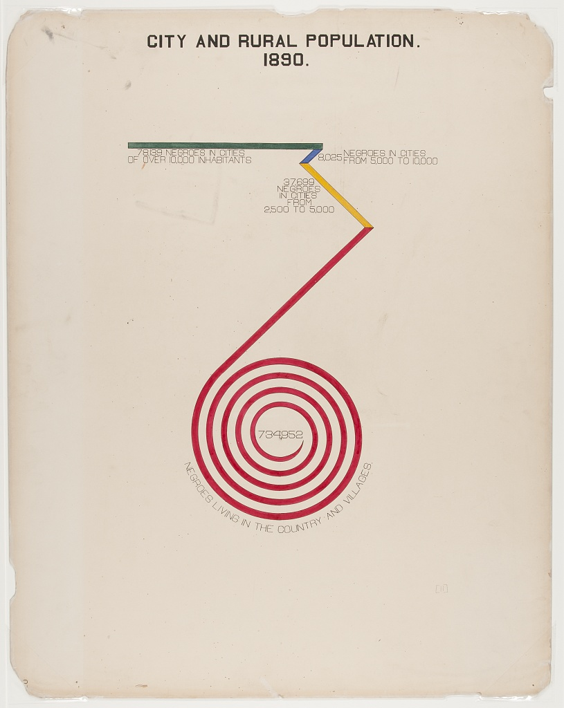

[Plate 11](https://www.loc.gov/pictures/collection/anedub/item/2013650430/)

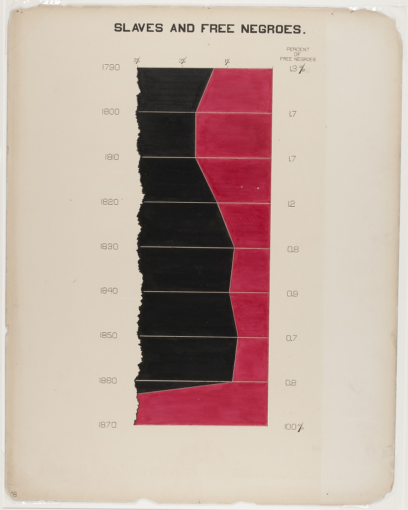

[Plate 12](https://www.loc.gov/pictures/collection/anedub/item/2013650431/)

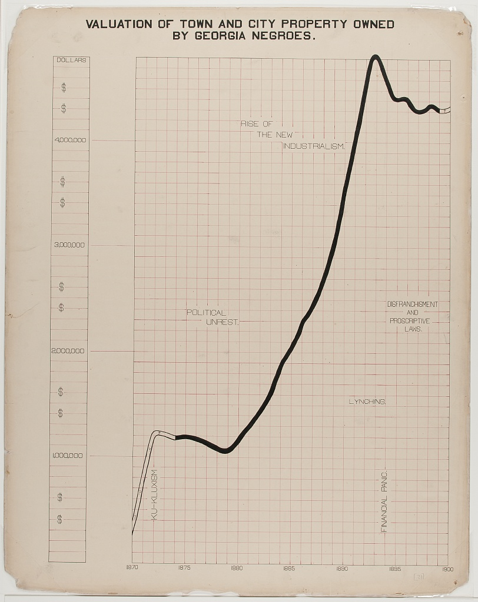

[Plate 21](https://www.loc.gov/pictures/collection/anedub/item/2013650441/)

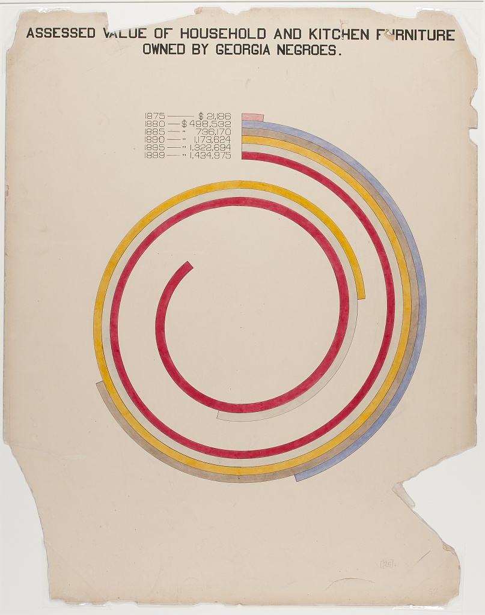

[Plate 25](https://www.loc.gov/pictures/collection/anedub/item/2013650445/)

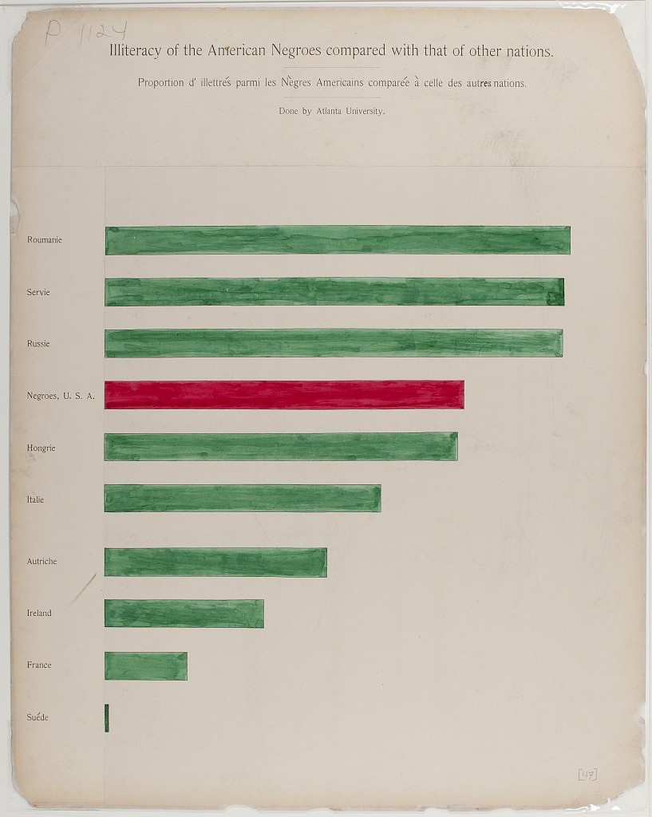

[Plate 47](https://www.loc.gov/pictures/collection/anedub/item/2014645352/)

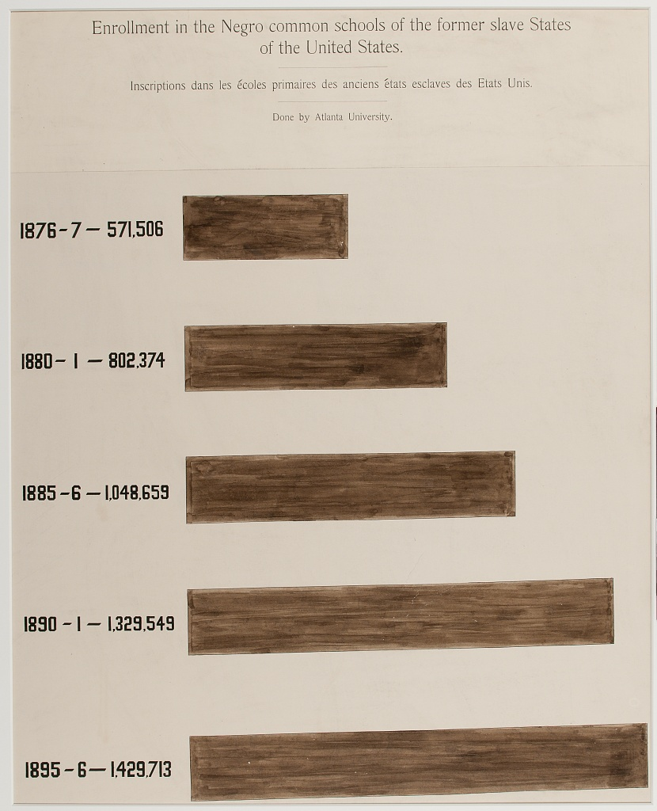

[Plate 48](https://www.loc.gov/pictures/collection/anedub/item/2014645353/)

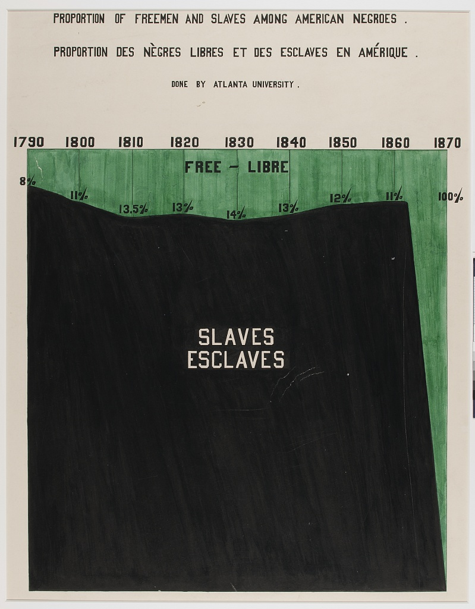

[Plate 51](https://www.loc.gov/pictures/collection/anedub/item/2014645356/)

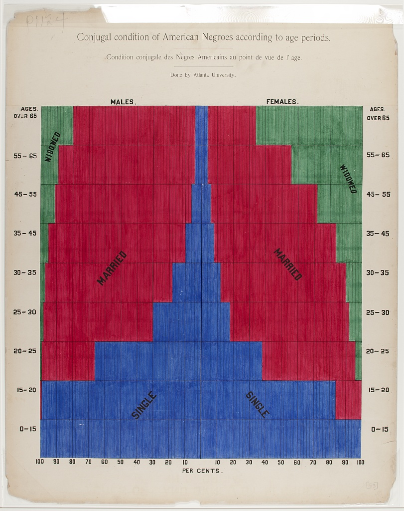

[Plate 53](https://www.loc.gov/pictures/collection/anedub/item/2014645358/)

## References

Battle-Baptiste, W. and Rusert, B. eds., 2018. WEB Du Bois’s data portraits: Visualizing black America. Chronicle Books.

Du Bois, W.E.B., 1900. African American photographs assembled for 1900 Paris Exposition. Library of Congress, Washington, DC [online](https://www.loc.gov/pictures/collection/anedub)

Provenzo, E.F., 2023. WEB DuBois’s Exhibit of American Negroes: African Americans at the Beginning of the Twentieth Century. Rowman & Littlefield.